# Finding the Shortest Path with R

# Matrix Representation of a Graph

- The below code will generate a random adjacency matrix. This function can scale efficiently to ~ 500 columns and rows on my machine:

```r
createAdjMatrix = function(n){               # n = number of columns and rows
  d = runif(n*n)                             # generate random data from 0-1
  d[d < .8] = NA                             # 20% chance of adjacency
  d = matrix(d, nrow = n)                    # form data into a square matrix
  diag(d) = NA                               # make diagonal into NAs
  d[upper.tri(d)] = t(d)[upper.tri(d)]       # make upper & lower triangles adjacent
  return(d)                                     # i.e distance 1->3 is the same as 3->1
}
testmatrix = createAdjMatrix(5)
kable(testmatrix, digits = 2, caption = 'Adjacency Matrix')
```

Adjacency Matrix

| NA | NA | NA | 0.91 | NA |
| --- | --- | --- | --- | --- |
| NA | NA | NA | NA | NA |
| NA | NA | NA | 0.89 | 0.86 |
| 0.91 | NA | 0.89 | NA | NA |
| NA | NA | 0.86 | NA | NA |

- The next step in the workbook is to translate the above adjacency matrix into an adjacency list representation:

```r
AdjMatrix2List <- function(d){               # d = adjacency matrix, use above function
  x = vector()                               # initialize empty vector to store results
  for (i in 1:nrow(d)){                      # loop through row
    for (j in 1:ncol(d)){                    # loop over each column value in row
      if(!is.na(d[i,j])){                    # skip over NAs/values without adjacency
        x = c(x, i, j, d[i,j])               # appending the row, column, & value
      }
    }
  }
  labs = c('head', 'tail', 'weight')         # column names for results matrix
  ds = matrix(x, ncol = 3, byrow = TRUE)     # shape result vector into a 3 column matrix
  colnames(x = ds) = labs                    # add column labels
  return(ds)
}

#testmatrix = createAdjMatrix(100)            # create matrix with n rows/columns
kable(AdjMatrix2List(testmatrix),
      digits = 2,
      caption = 'Adjacency List Representation')
```

Adjacency List Representation

| head | tail | weight |
| --- | --- | --- |
| 1 | 4 | 0.91 |
| 3 | 4 | 0.89 |
| 3 | 5 | 0.86 |
| 4 | 1 | 0.91 |
| 4 | 3 | 0.89 |
| 5 | 3 | 0.86 |

# Euclidean Minimum Spanning Tree

In this exercise, I will create a Euclidean Minimum Spanning Tree (E-MST) on a set of random (X, Y) coordinates. One can think of each of these coordinates as locations for a facility where we want to build and visualize a road network that connects all of these facilities at minimum cost.

- I will first create a set of 50 random X,Y coordinates to represent 50 facilities that we want to efficiently connect (minimum cost).

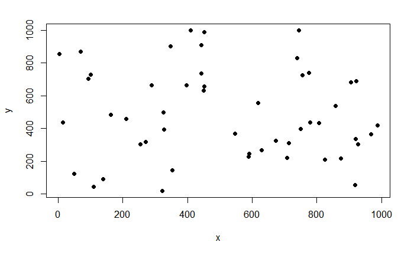

```r
n <- 50                                      # number of points to generate
x <- round(runif(n)*1000)
y <- round(runif(n)*1000)
plot(x,y,pch=16)
```

- The following code generates a complete graph of the distances between all 50 facilities (generated above). This is a complete graph because it calculates the distance between every single facility - resulting in an adjacency matrix that is full, except for 0’s along the diagonal (when a facility is paired with itself).

```r
hold = vector()                               # initialize empty vector to store results

for (i in 1:n){                               # set point 1
  for (j in 1:n){                             # set point 2
    dist = sqrt(((y[j] - y[i])**2) +          # calculate euclidean distance
                  ((x[j] - x[i])**2))
    hold = c(hold, dist)                      # append distance to results vector
  }
}

matrixlabs = paste('(',x,',',y,')',sep ='')   # generate coordinate labels
holdresults = matrix(hold, ncol = n,          # shape results into square matrix
                     byrow = TRUE,
                     dimnames = list(matrixlabs,matrixlabs))

kable(head(holdresults[,1:5]),
      digits = 2, caption = 'Complete Adjacency Matrix')
```

Complete Adjacency Matrix

|  | (442,736) | (3,856) | (100,729) | (397,663) | (739,829) |
| --- | --- | --- | --- | --- | --- |
| (442,736) | 0.00 | 455.11 | 342.07 | 85.76 | 311.22 |
| (3,856) | 455.11 | 0.00 | 159.81 | 438.73 | 736.50 |
| (100,729) | 342.07 | 159.81 | 0.00 | 304.24 | 646.78 |
| (397,663) | 85.76 | 438.73 | 304.24 | 0.00 | 380.16 |
| (739,829) | 311.22 | 736.50 | 646.78 | 380.16 | 0.00 |
| (321,19) | 727.14 | 895.37 | 743.60 | 648.47 | 911.50 |

- I will now use the AdjMatrix2List function (created above) to transform this complete adjacency matrix into an adjacency list:

```r
ds = AdjMatrix2List(holdresults)
kable(head(ds), caption = 'Complete Adjacency List')
```

Complete Adjacency List

| head | tail | weight |
| --- | --- | --- |
| 1 | 1 | 0.00000 |
| 1 | 2 | 455.10548 |
| 1 | 3 | 342.07163 |
| 1 | 4 | 85.75547 |
| 1 | 5 | 311.22018 |
| 1 | 6 | 727.13823 |

- This format now allows me to calculate the minimum spanning tree (the most efficient path between the facilities). This will be calculated using the Dijkstra-Prim algorithm that is found in the ‘optrees’ package.

```r
ds.mst = msTreePrim(nodes = 1:n,              # calculate minimum spanning tree
                    arcs = ds)                # arcs = adjacency list created above
route = ds.mst$tree.arcs                      # pull the route (from-to) from results
head(route)                                   # ept1 = starting node | ept2 = ending node
```

```
     ept1 ept2    weight
[1,]    1   19  80.62258
[2,]   19   28  24.18677
[3,]   19    4  55.44367
[4,]    4   22 108.00463
[5,]   22   23 170.07351
[6,]   23   30 104.01923
```

- This information can be used to graphically represent the most efficient route through the facilities:

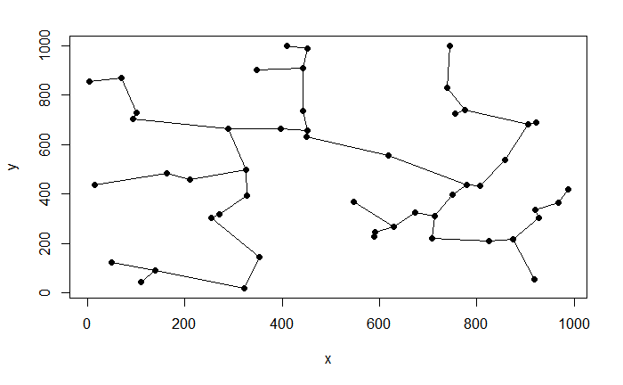

```r
plot.mst = function(route){
  segments(x[route[,1]], y[route[,1]],x[route[,2]],y[route[,2]])
}
plot(x,y,pch=16)
plot.mst(route)
```